# 政治学方法論I：課題３

提出者：宋財泫(ソン・ジェヒョン)

提出日：2014年10月17日(金)

## 全問共通

```r
#==========================================================
# File: 03.HW03.R
# Working directory: /Users/Jaehyun/Dropbox/Graduate School
#                    /Political Methodology I/2014(Yanai)
# Title: Research methods in Poltical Science - Homework 03
# Date: 2014-10-15
# Modified : 2014-10-19
# Author : Jaehyun Song
#==========================================================

# Call "ggplot2" due to creating graphs
require(ggplot2)
```

## 問題１

- 階乗を計算する関数を作りなさい。
1. 関数の名前は`Jay.factorial`と命名し、引数は*x*と指定する。
2. 戻り値は*return*であり、掛け算のために最初の段階で１を割り当てる。
3. `if`関数で条件付き分岐をする。
   1. 引数が0より小さい場合はエラーメッセージを出力する。(`if(x < 0)`の部分)
   2. 引数が0の場合は１を返する。(`else if(x == 0)`の部分)
   3. 引数が0より大きい場合はべき乗の演算($n! = n(n-1)(n-2)...1$)を行い、その結果を返す。(`else`の部分)

```r
#=================
# Probelm 1
#=================

#To define a function, called "Jay.factorial", which perfome a function same as "factorial" in R
Jay.factorial <- function(x){
  # Argument：x (integer)
  # Return value：result

  result <- 1 # To declare the return value

  if(x < 0){       # The case which the argument is less than zero
    #Display an error message
    print("The argument must be greater than ZERO.")
  }

  else if(x == 0){ #If x equals to zero
    return(1) # Return 1
  }

  else{            # If the argument is greater than zero
    for(i in x:1){
      result <- result * i # Multiply "i" and the previous value, "result"
    }
    return(result) #Return the result
  }
}
```

最後にRの内蔵関数(`factorial`)と自作関数の結果を比較する。

```r
#Comparison between the user defiend function, Jay.factorial, and factorial in R
factorial(10) == Jay.factorial(10)
```

```
## [1] TRUE
```

## 問題２

- 自分で作った階乗の関数を利用して、組み合わせを計算する関数を作りなさい。
1. 組み合わせを演算するユーザー定義関数を*Jay.choose*と命名し、因数は*n*と*k*にする。これは*n*個のものから*k*個のものを選ぶ事を意味する。
2. `if`関数で条件付き分岐をする。
   1. *k*が*n*より大きい場合、0を返す。(`if(n < k)`の部分)
   2. それ以外の場合は組合せの演算を行う。(`else`の部分) 組合せの公式は$\begin{pmatrix} n \\ k \end{pmatrix}=\frac { n! }{ k!(n-k)! }$である。べき乗の演算は`Jay.factorial()`で処理する。
   3. 結果は*result*に書き込まれ、最後に*result*の値を返す。(`return(result)`の部分)

```r
#=================
# Probelm 2
#=================

#To define a function, called "Jay.choose", which perfome a function same as "choose" in R
Jay.choose <- function(n, k){
  # Arguments: n, k
  # Retrun value：result

  if(n < k){  # if k is greater than n
    return(0) # return "0"
  }

  else{       #If n is greater than k
    # Calculate combination
    result <- Jay.factorial(n) / (Jay.factorial(k) * Jay.factorial(n-k))

    return(result) # Return the result
  }
}
```

最後にRの内蔵関数(`choose`)と自作関数の結果を比較する。

```r
#Comparison between the user defiend function, Jay.factorial, and factorial in R
choose(10, 5) == Jay.choose(10, 5)
```

```
## [1] TRUE
```

## 問題３

- 自分で作った組み合わせの関数を利用して、二項分布の確率質量を求める関数を作りなさい。
1. 二項分布の確率質量を求めるユーザー定義関数を*Jay.dbinom*と命名し、因数は*x*、*n*、*p*とする。*x*は成功回数であり、*n*は試行回数、*p*は成功確率である。
2. 確率質量を求めるために$f\left( x \right) =\begin{pmatrix} n \\ x \end{pmatrix}{ p }^{ x }{ (1-p) }^{ n-x }\quad (x=0,1,2,...,n)$の演算を行う。組合せは問題２の`Jay.choose`を利用して演算する。
3. 最後に結果を*result*に書き込み、返す。

```r
#=================
# Probelm 3
#=================

#To define a function, called "Jay.dbinom", which perfome a function same as "dbinom" in R
Jay.dbinom <- function(x, n, p){
  # Arguments: x - number of success (integer)
  #            n - number of bernoulli trials (integer)
  #            p - probability of success (integer)
  # Return Value: result

    # Calculate the binomial probability
    result <- Jay.choose(n, x) * p^x * (1-p)^(n-x)

  return(result)
}
```

最後にRの内蔵関数(`dbinom`)と自作関数の結果を比較する。

```r
#Comparison between the user defiend function, Jay.factorial, and factorial in R
dbinom(1, 10, .5) == Jay.dbinom(1, 10, .5) # This result can be ignored
```

```
## [1] FALSE
```

比較の結果、内臓関数と自作関数の値が一致しないことが確認できる。しかし、これは丸めの問題である可能性が高いため、個別的に検証する。

```r
dbinom(1, 10, .5)
```

```
## [1] 0.009766
```

```r
Jay.dbinom(1, 10, .5)
```

```
## [1] 0.009766
```

## 問題４

- 自分で作った二項分布の関数を使い、n が 2, 3, 5, 10 の場合について、確率質量を図示しなさい。p の値については任意とする。ただし、2 つ以上の p で図を作りなさい。その際、forループを少なくとも 1 回使いなさい。

最初に二項分布の確率質量を書き込むためのデータフレームを生成する。ここでは最終的に使うデータフレーム*final.data.frame*とループ文内で使用する*temp.data.frame*を生成した。*temp.data.frame*は第１行のみを使い上書きするため欠損値(NA)で生成したが、*final.data.frame*は`rbind()`コマンドを用いて結合させるためNULLで設定する。

```r
#=================
# Probelm 4
#=================

# Creat an empty data frame called "temp.data.frame" (Temporary data)
temp.data.frame <- data.frame(p=NA, n=NA, x=NA, result=NA)
# Creat an empty data frame called "final.data.frame" (Full data)
final.data.frame <- data.frame(p=NULL, n=NULL, x=NULL, result=NULL)
```

成功確率*p*, 試行回数*n*, 成功回数*x*、それぞれに対してループを使うため３つのfor文を用いる。これらは独立しているわけではなく、三重構造になる。３つ目のfor文の中では臨時データフレーム, *temp.data.frame*に*p*, *n*, *x*, 確率質量を書き込み、次は`rbind()`コマンドを使用して*final.data.frame*の最後業に追加する。確率質量は問題３のユーザー定義関数である`Jay.dbninom()`を利用する。

```r
for(p in c(0.5, 0.8)){         # Loop for p = 0.5 and p = 0.8
  for(i in c(2, 3, 5, 10)){    # Loop for n = 2, 3, 5, 10
    for(j in 0:i){             # Loop for x = 0 ~ n

      # Input p, n, x, and result into the temporary data frame
      temp.data.frame[1, ] <- c(paste("p =", p), paste("n =", i), j, Jay.dbinom(j, i, p))

      # Combining final.data.frame with temp.data.frame
      final.data.frame <- rbind(final.data.frame, temp.data.frame)
    }
  }
}
```

この過程によって生成された*final.data.frame*は中身は以下のようである。

```r
# Display first six data in "final.data.frame"
head(final.data.frame)
```

```
##         p     n x result
## 1 p = 0.5 n = 2 0   0.25
## 2 p = 0.5 n = 2 1    0.5
## 3 p = 0.5 n = 2 2   0.25
## 4 p = 0.5 n = 3 0  0.125
## 5 p = 0.5 n = 3 1  0.375
## 6 p = 0.5 n = 3 2  0.375
```

```r
# Display last six data in "final.data.frame"
tail(final.data.frame)
```

```
##          p      n  x       result
## 43 p = 0.8 n = 10  5 0.0264241152
## 44 p = 0.8 n = 10  6  0.088080384
## 45 p = 0.8 n = 10  7  0.201326592
## 46 p = 0.8 n = 10  8  0.301989888
## 47 p = 0.8 n = 10  9  0.268435456
## 48 p = 0.8 n = 10 10 0.1073741824
```

*final.data.frame*の中身は数値データではなく文字データとして書き込まれているため、このまま`ggplot`を用いて４つのグラフを表示させると*n=10*, *n=2*, *n=3*, *n=5*の順番で表示される。これを避けるために*final.data.frame*の*n*列のデータをfactor型へ変換し、順序付けする。

```r
# Factoring the column, "n", in order to order the plots
final.data.frame$n <- factor(final.data.frame$n,
                             levels = c("n = 2", "n = 3", "n = 5", "n = 10"))
```

結果グラフを表示する。作図をする前に２つの図において共通的に使われるオプションを一つのオブジェクトに収める。そのためにリスト型のオブジェクト(*prob4.opts*)を生成し、その中にオプションを書き込む。

```r
# Save option components into an object called "prob4.opts"
prob4.opts <- list(geom_bar(aes(x = as.integer(x), y = as.numeric(result)), stat="identity"),
                   facet_wrap(~n), ylab("Probability"), xlab("Number of success"))
```

成功確率(*p*)に分けて作図するため、同一データフレーム内の異なる行のデータ(1 ~ 24行：*p = 0.5*, 24 ~ 48行：*p = 0.8*)を用いる。

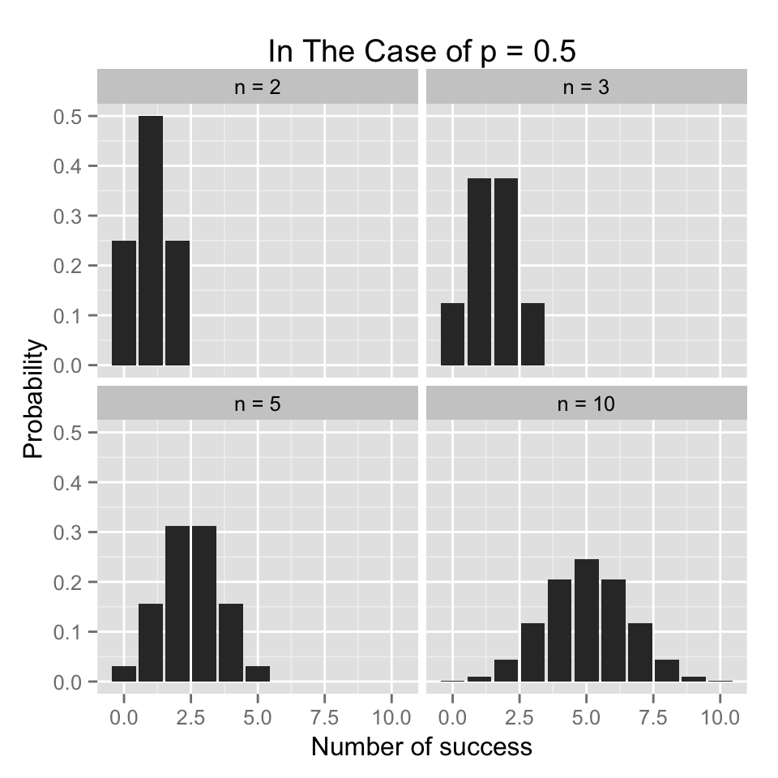

```r
# Display the plot of "p = 0.5" with dividing by "n"
ggplot(data=final.data.frame[1:24, ]) + prob4.opts + ggtitle("In The Case of p = 0.5")
```

以上は*p = 0.5*の場合の二項分布の確率質量である。

続いて、*p = 0.8*の場合の確率質量の棒グラフを表示する。

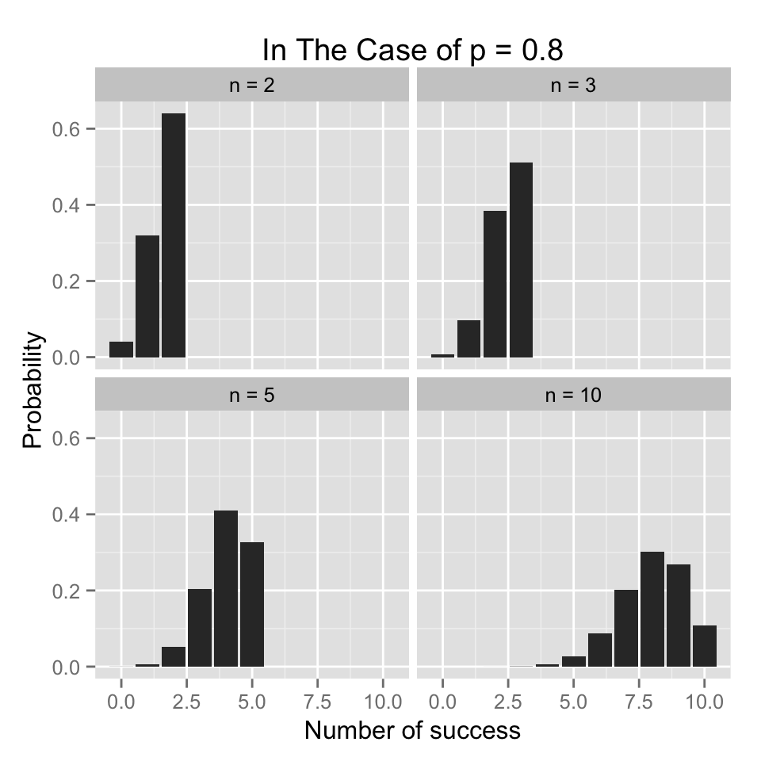

```r
# Display the plot of "p = 0.8" with dividing by "n"
ggplot(data=final.data.frame[25:48, ]) + prob4.opts + ggtitle("In The Case of p = 0.8")
```